# My initial questions about the baseball salaries dataset:

# New question:

I wanted to answer the question, which came mid-way through my analysis, of whether teams that win the World Series spend more on player salaries than the other teams. I will attempt to answer this question. I am assuming that the total amounts teams spend on salaries in a particular year is approximately normally distributed.

```python
# Load dataset about playoff performance:

playoffs_filepath = '/Users/AndrewBryant/Documents/Udacity/P2/baseballdatabank-master/core/SeriesPost.csv'
playoffs = pd.DataFrame.from_csv(playoffs_filepath, index_col = None)
playoffs.head()
```

|  | yearID | round | teamIDwinner | lgIDwinner | teamIDloser | lgIDloser | wins | losses | ties |
| --- | --- | --- | --- | --- | --- | --- | --- | --- | --- |
| 0 | 1884 | WS | PRO | NL | NYP | AA | 3 | 0 | 0 |
| 1 | 1885 | WS | CHC | NL | STL | AA | 3 | 3 | 1 |
| 2 | 1886 | WS | STL | AA | CHC | NL | 4 | 2 | 0 |
| 3 | 1887 | WS | DTN | NL | STL | AA | 10 | 5 | 0 |
| 4 | 1888 | WS | NYG | NL | STL | AA | 6 | 4 | 0 |

# Checking for missing values:

There are no missing values. Each column contains 307 values. However, it is important to note there was no World Series in 1994 due to a player strike.

```python
playoffs.info()
```

```
<class 'pandas.core.frame.DataFrame'>
RangeIndex: 307 entries, 0 to 306
Data columns (total 9 columns):
yearID          307 non-null int64
round           307 non-null object
teamIDwinner    307 non-null object
lgIDwinner      307 non-null object
teamIDloser     307 non-null object
lgIDloser       307 non-null object
wins            307 non-null int64
losses          307 non-null int64
ties            307 non-null int64
dtypes: int64(4), object(5)
memory usage: 21.7+ KB
```

### Since the salary data only goes back to 1985, I only examine World Series from 1985 onward.

Create variables containing the value of how much each team spent on player salaries for a given year.

```python
# View recent World Series data:

recent_playoffs = playoffs[playoffs['yearID'] >= 1985]
recent_world_series = recent_playoffs[recent_playoffs['round'] == 'WS']
recent_world_series
```

|  | yearID | round | teamIDwinner | lgIDwinner | teamIDloser | lgIDloser | wins | losses | ties |
| --- | --- | --- | --- | --- | --- | --- | --- | --- | --- |
| 127 | 1985 | WS | KCA | AL | SLN | NL | 4 | 3 | 0 |
| 130 | 1986 | WS | NYN | NL | BOS | AL | 4 | 3 | 0 |
| 133 | 1987 | WS | MIN | AL | SLN | NL | 4 | 3 | 0 |
| 136 | 1988 | WS | LAN | NL | OAK | AL | 4 | 1 | 0 |
| 139 | 1989 | WS | OAK | AL | SFN | NL | 4 | 0 | 0 |
| 142 | 1990 | WS | CIN | NL | OAK | AL | 4 | 0 | 0 |
| 145 | 1991 | WS | MIN | AL | ATL | NL | 4 | 3 | 0 |
| 148 | 1992 | WS | TOR | AL | ATL | NL | 4 | 2 | 0 |
| 151 | 1993 | WS | TOR | AL | PHI | NL | 4 | 2 | 0 |
| 158 | 1995 | WS | ATL | NL | CLE | AL | 4 | 2 | 0 |
| 165 | 1996 | WS | NYA | AL | ATL | NL | 4 | 2 | 0 |
| 172 | 1997 | WS | FLO | NL | CLE | AL | 4 | 3 | 0 |
| 179 | 1998 | WS | NYA | AL | SDN | NL | 4 | 0 | 0 |
| 186 | 1999 | WS | NYA | AL | ATL | NL | 4 | 0 | 0 |
| 193 | 2000 | WS | NYA | AL | NYN | NL | 4 | 1 | 0 |
| 200 | 2001 | WS | ARI | NL | NYA | AL | 4 | 3 | 0 |
| 207 | 2002 | WS | ANA | AL | SFN | NL | 4 | 3 | 0 |
| 214 | 2003 | WS | FLO | NL | NYA | AL | 4 | 2 | 0 |
| 221 | 2004 | WS | BOS | AL | SLN | NL | 4 | 0 | 0 |
| 228 | 2005 | WS | CHA | AL | HOU | NL | 4 | 0 | 0 |
| 235 | 2006 | WS | SLN | NL | DET | AL | 4 | 1 | 0 |
| 242 | 2007 | WS | BOS | AL | COL | NL | 4 | 0 | 0 |
| 249 | 2008 | WS | PHI | NL | TBA | AL | 4 | 1 | 0 |
| 256 | 2009 | WS | NYA | AL | PHI | NL | 4 | 2 | 0 |
| 263 | 2010 | WS | SFN | NL | TEX | AL | 4 | 1 | 0 |
| 270 | 2011 | WS | SLN | NL | TEX | AL | 4 | 3 | 0 |
| 279 | 2012 | WS | SFN | NL | DET | AL | 4 | 0 | 0 |
| 288 | 2013 | WS | BOS | AL | SLN | NL | 4 | 3 | 0 |
| 297 | 2014 | WS | SFN | NL | KCA | AL | 4 | 3 | 0 |
| 306 | 2015 | WS | KCA | AL | NYN | NL | 4 | 1 | 0 |

```python
# Summed player salaries by team 1985-2015:

sum_salaries_by_team_2015 = s[s['yearID'] == 2015]
sum_salaries_by_team_2014 = s[s['yearID'] == 2014]
sum_salaries_by_team_2013 = s[s['yearID'] == 2013]
sum_salaries_by_team_2012 = s[s['yearID'] == 2012]
sum_salaries_by_team_2011 = s[s['yearID'] == 2011]
sum_salaries_by_team_2010 = s[s['yearID'] == 2010]
sum_salaries_by_team_2009 = s[s['yearID'] == 2009]
sum_salaries_by_team_2008 = s[s['yearID'] == 2008]
sum_salaries_by_team_2007 = s[s['yearID'] == 2007]
sum_salaries_by_team_2006 = s[s['yearID'] == 2006]
sum_salaries_by_team_2005 = s[s['yearID'] == 2005]
sum_salaries_by_team_2004 = s[s['yearID'] == 2004]
sum_salaries_by_team_2003 = s[s['yearID'] == 2003]
sum_salaries_by_team_2002 = s[s['yearID'] == 2002]
sum_salaries_by_team_2001 = s[s['yearID'] == 2001]
sum_salaries_by_team_2000 = s[s['yearID'] == 2000]
sum_salaries_by_team_1999 = s[s['yearID'] == 1999]
sum_salaries_by_team_1998 = s[s['yearID'] == 1998]
sum_salaries_by_team_1997 = s[s['yearID'] == 1997]
sum_salaries_by_team_1996 = s[s['yearID'] == 1996]
sum_salaries_by_team_1995 = s[s['yearID'] == 1995]
sum_salaries_by_team_1994 = s[s['yearID'] == 1994]
sum_salaries_by_team_1993 = s[s['yearID'] == 1993]
sum_salaries_by_team_1992 = s[s['yearID'] == 1992]
sum_salaries_by_team_1991 = s[s['yearID'] == 1991]
sum_salaries_by_team_1990 = s[s['yearID'] == 1990]
sum_salaries_by_team_1989 = s[s['yearID'] == 1989]
sum_salaries_by_team_1988 = s[s['yearID'] == 1988]
sum_salaries_by_team_1987 = s[s['yearID'] == 1987]
sum_salaries_by_team_1986 = s[s['yearID'] == 1986]
sum_salaries_by_team_1985 = s[s['yearID'] == 1985]
```

# Creating Z-Scores:

The function "standardize" standardizes the player salaries of the World Series winner with other teams' salaries for that year. The function takes the winning teams's ID and the corresponding year's summed salaries by team data frame and returns a z-score of a team's player salary spending relative to other teams for that year.

```python
def standardize(winner_id, sum_salaries_by_team_x):
    winner_salary = float(sum_salaries_by_team_x[sum_salaries_by_team_x['teamID'] == winner_id]['salary'])
    sum_salaries_by_team_x_mean = sum_salaries_by_team_x.mean()
    sum_salaries_by_team_x_std = sum_salaries_by_team_x.std()
    z_score = (winner_salary - sum_salaries_by_team_x_mean) / sum_salaries_by_team_x_std
    return(z_score['salary'])

# Create variables using output of standardize:

kca_1985 = standardize('KCA', sum_salaries_by_team_1985)
nyn_1986 = standardize('NYN', sum_salaries_by_team_1986)
min_1987 = standardize('MIN', sum_salaries_by_team_1987)
lan_1988 = standardize('LAN', sum_salaries_by_team_1988)
oak_1989 = standardize('OAK', sum_salaries_by_team_1989)
cin_1990 = standardize('CIN', sum_salaries_by_team_1990)
min_1991 = standardize('MIN', sum_salaries_by_team_1991)
tor_1992 = standardize('TOR', sum_salaries_by_team_1992)
tor_1993 = standardize('TOR', sum_salaries_by_team_1993)
atl_1995 = standardize('ATL', sum_salaries_by_team_1995)
nya_1996 = standardize('NYA', sum_salaries_by_team_1996)
flo_1997 = standardize('FLO', sum_salaries_by_team_1997)
nya_1998 = standardize('NYA', sum_salaries_by_team_1998)
nya_1999 = standardize('NYA', sum_salaries_by_team_1999)
nya_2000 = standardize('NYA', sum_salaries_by_team_2000)
ari_2001 = standardize('ARI', sum_salaries_by_team_2001)
ana_2002 = standardize('ANA', sum_salaries_by_team_2002)
flo_2003 = standardize('FLO', sum_salaries_by_team_2003)
bos_2004 = standardize('BOS', sum_salaries_by_team_2004)
cha_2005 = standardize('CHA', sum_salaries_by_team_2005)
sln_2006 = standardize('SLN', sum_salaries_by_team_2006)
bos_2007 = standardize('BOS', sum_salaries_by_team_2007)
phi_2008 = standardize('PHI', sum_salaries_by_team_2008)
nya_2009 = standardize('NYA', sum_salaries_by_team_2009)
sfn_2010 = standardize('SFN', sum_salaries_by_team_2010)
sln_2011 = standardize('SLN', sum_salaries_by_team_2011)
sfn_2012 = standardize('SFN', sum_salaries_by_team_2012)
bos_2013 = standardize('BOS', sum_salaries_by_team_2013)
sfn_2014 = standardize('SFN', sum_salaries_by_team_2014)
kca_2015 = standardize('KCA', sum_salaries_by_team_2015)
```

```python
# Create variables to be used in future plots:

all_winners = np.array([kca_1985, nyn_1986, min_1987, lan_1988, oak_1989,
                        cin_1990, min_1991, tor_1992, tor_1993, atl_1995,
                        nya_1996, flo_1997, nya_1998, nya_1999, nya_2000,
                        ari_2001, ana_2002, flo_2003, bos_2004, cha_2005,
                        sln_2006, bos_2007, phi_2008, nya_2009, sfn_2010,
                        sln_2011, sfn_2012, bos_2013, sfn_2014, kca_2015])
world_series_years = np.array([1985, 1986, 1987, 1988, 1989, 1990, 1991, 1992, 1993, 1995, 1996, 1997, 1998, 1999, 2000,
                              2001, 2002, 2003, 2004, 2005, 2006, 2007, 2008, 2009, 2010, 2011,
                              2012, 2013, 2014, 2015])

all_winners_df = pd.DataFrame(
    data = {'z_scores': [kca_1985, nyn_1986, min_1987, lan_1988, oak_1989,
                        cin_1990, min_1991, tor_1992, tor_1993, atl_1995,
                        nya_1996, flo_1997, nya_1998, nya_1999, nya_2000,
                        ari_2001, ana_2002, flo_2003, bos_2004, cha_2005,
                        sln_2006, bos_2007, phi_2008, nya_2009, sfn_2010,
                        sln_2011, sfn_2012, bos_2013, sfn_2014, kca_2015]},
    index = world_series_years)

z_scores = all_winners_df['z_scores']
```

# Boxplot of Z-scores:

The below boxplot is of the z-scores of the sum of the salaries of World Series-winning teams compared to all other teams for a particular season. It appears that the majority of teams that won the world series spent more than average on player salaries in the year that they won the championship.

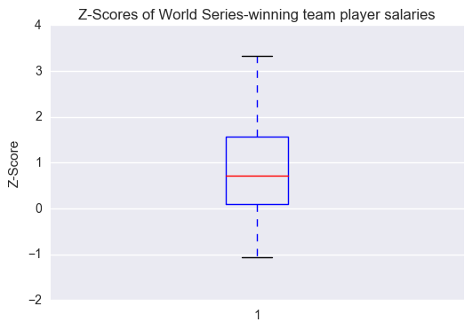

```python
# Plot boxplot:

plt.boxplot(all_winners)
plt.title('Z-Scores of World Series-winning team player salaries')
plt.ylabel('Z-Score')
plt.grid(axis = 'x')
```

# Scatter plot of z-scores:

Below are the z-scores represented as a scatter plot. There doesn't appear to be much of a correlation between time and z-score. This could imply that most teams are spending more or less money at the same time. For example, if one team the World Series back-to-back using the same amount for salaries in both years, and every other team increased its total salary amount between the first and second year, the z-score of the World Series-winner would be lower in the second year than in the first.

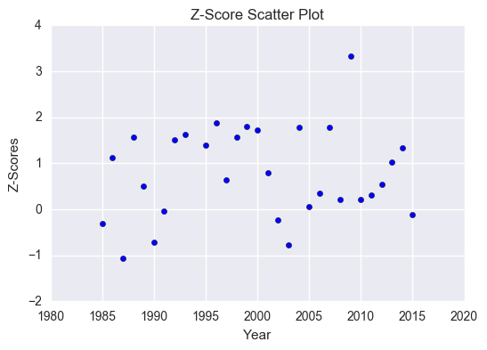

```python
plt.scatter(world_series_years, z_scores)
plt.title('Z-Score Scatter Plot')
plt.xlabel('Year')
plt.ylabel('Z-Scores')
```

# Limitations and Further Research:

Limitations of the salary dataset are an absence of contract data, and a lack of separation of base salary and any bonuses that a player might earn. This data would add context and understanding to a player's salary. For example, Alex Rodriguez is not only the player with the highest salary in the dataset, but his 10-year, $275 million contract is one of the largest contracts ever, in any sport.

For the playoff data, it would be nice to have the final score of the games, as well as the probability that each team would win. The latter might only be available for more recent years, but it would be interesting to use that data to compare how people's predictions fared against actual game outcomes.

The study of the relationship between World Series wins and salary spending only examines correlation; no conclusions should be drawn from it.

Further research could help answer the question of whether there is a causal link between performance and spending on player salaries. Additionally, my questions focused on player salaries. Other interesting questions that don't involve money are what position has players with the highest batting average, as well as whether a team's moving cities affect a team's performance?

# Sources:

http://www.baseball-reference.com/players/j/jamesdi01.shtml http://www.baseball-reference.com/teams/PIT/1999.shtml http://www.smh.com.au/sport/top-10-largest-sports-contracts-20141118-11oz2n.html http://thefinancebase.com/calculate-annual-inflation-over-multiple-years-2088.html https://data.bls.gov/timeseries/CUSR0000SA0?output_view=pct_1mth https://www.bls.gov/data/inflation_calculator.htm http://www.bankofengland.co.uk/education/Pages/resources/inflationtools/calculator/how.aspx